# Demographics: PFAS and MMIP DNAm data (BS only!)

Rebekah Petroff

9/13/2021

This document is the key to building all of our tables for the manuscript describing the exposure and demographics of the subset of MMIP used for PFAS and EPIC analysis.

## Exposures

For exposures, the first question to consider is if we should drop any of those exposures. Our analysis plan is to keep any variables as is with at least 60% of samples above the LOD. Additionally, any samples that are less than 60% detected above the LOD but more than 20% detected will be dichotomized (detected yes/no). Given these criteria, the following will happen to the variables:

[output not shown]

$$\\[0.5in]$$

All of this is based on a total MMIP sample size with PFAS measurements and passing EPIC data of:

```
[1] 141
```

$$\\[0.5in]$$

For the exposure variables we are keeping, the variables can be described as follows (reported in untransformed values, with LOD replaced by LOD/sqrt(2)):

|  | Exposure | n | GM | GSD | Mean | Min | Max |
| --- | --- | --- | --- | --- | --- | --- | --- |
| 1 | MePFOSA | 141 | 0.107 | 1.96 | 0.155 | 0.071 | 2.608 |
| 2 | PFDeA | 141 | 0.124 | 1.77 | 0.148 | 0.071 | 0.583 |
| 3 | PFHxS | 141 | 3.191 | 1.61 | 3.597 | 0.976 | 21.766 |
| 4 | PFNA | 141 | 0.365 | 1.75 | 0.421 | 0.071 | 1.263 |
| 5 | PFOA | 141 | 1.142 | 1.88 | 1.373 | 0.354 | 4.130 |
| 6 | PFOS | 141 | 5.253 | 1.74 | 6.014 | 0.625 | 22.256 |
| 7 | PFUA | 141 | 0.106 | 1.87 | 0.138 | 0.071 | 0.988 |

$$\\[0.5in]$$

**Visually, we can see that the distributions look like this:**

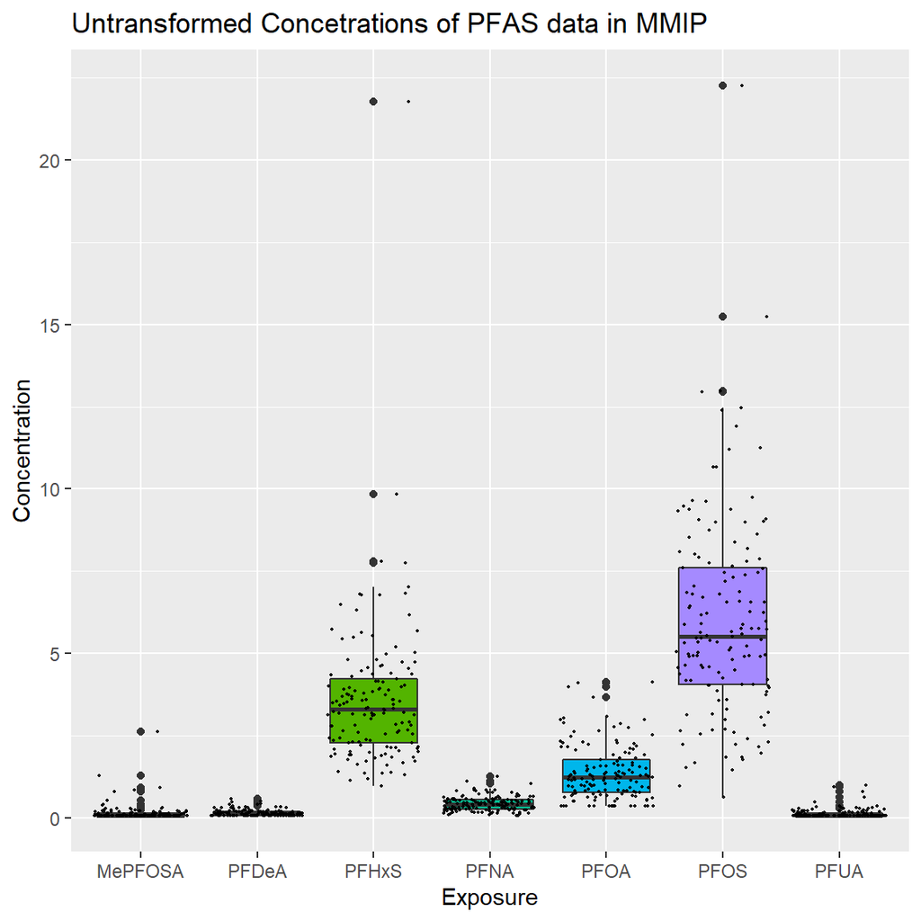

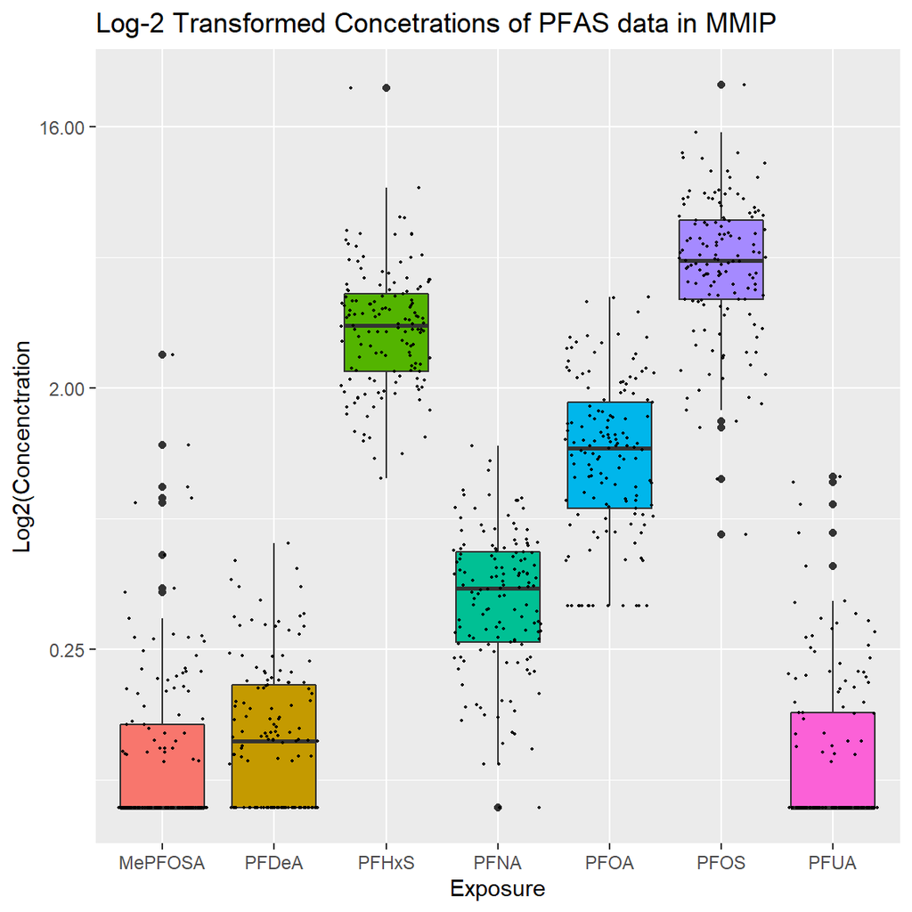

$$\\[0.5in]$$

**How are these exposures related to each other?**

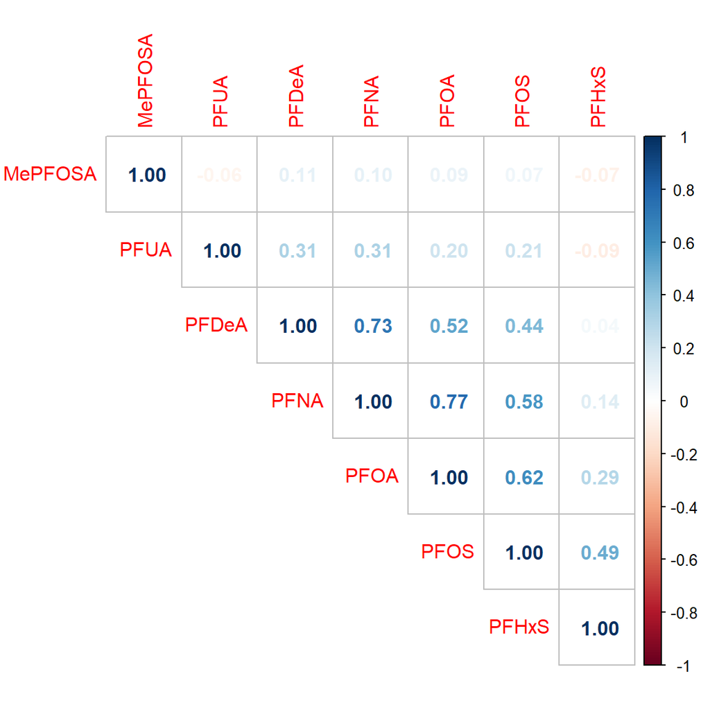

$$\\[0.5in]$$

$$\\[0.8in]$$

## Demographics

### Numeric Variables

First, for the numeric variables, we can look at the distributions a bit differently.

```
    Gravida         Parity      mtr_age_yrs    apgar_first     apgar_five
 Min.   :1.00   Min.   :0.00   Min.   :21.0   Min.   :1.00   Min.   : 3.00
 1st Qu.:1.00   1st Qu.:0.00   1st Qu.:29.0   1st Qu.:8.00   1st Qu.: 9.00
 Median :2.00   Median :1.00   Median :32.0   Median :8.00   Median : 9.00
 Mean   :2.16   Mean   :1.01   Mean   :31.8   Mean   :7.96   Mean   : 8.91
 3rd Qu.:3.00   3rd Qu.:1.00   3rd Qu.:34.0   3rd Qu.:9.00   3rd Qu.: 9.00
 Max.   :6.00   Max.   :4.00   Max.   :42.0   Max.   :9.00   Max.   :10.00
                               NA's   :1      NA's   :2      NA's   :2
 prepreg_wt_kg   postpreg_wt_kg    mtr_ht_cm    prepreg_BMI    gest_age_del
 Min.   : 45.0   Min.   : 57.0   Min.   :145   Min.   :19.1   Min.   :35.6
 1st Qu.: 59.0   1st Qu.: 72.9   1st Qu.:160   1st Qu.:21.9   1st Qu.:39.0
 Median : 65.0   Median : 80.0   Median :165   Median :24.0   Median :39.6
 Mean   : 70.6   Mean   : 84.3   Mean   :165   Mean   :25.8   Mean   :39.5
 3rd Qu.: 77.4   3rd Qu.: 90.2   3rd Qu.:170   3rd Qu.:28.4   3rd Qu.:40.3
 Max.   :145.0   Max.   :161.0   Max.   :188   Max.   :49.0   Max.   :41.9
                 NA's   :1       NA's   :3     NA's   :3
 no_days2deliv   brthwt_gms    birthlength      headcirc
 Min.   :249   Min.   :1885   Min.   :20.0   Min.   :25.5
 1st Qu.:273   1st Qu.:3130   1st Qu.:50.0   1st Qu.:33.8
 Median :277   Median :3480   Median :51.0   Median :34.5
 Mean   :277   Mean   :3435   Mean   :51.0   Mean   :34.6
 3rd Qu.:282   3rd Qu.:3710   3rd Qu.:53.0   3rd Qu.:35.5
 Max.   :293   Max.   :4685   Max.   :56.3   Max.   :38.6
                              NA's   :16     NA's   :12
```

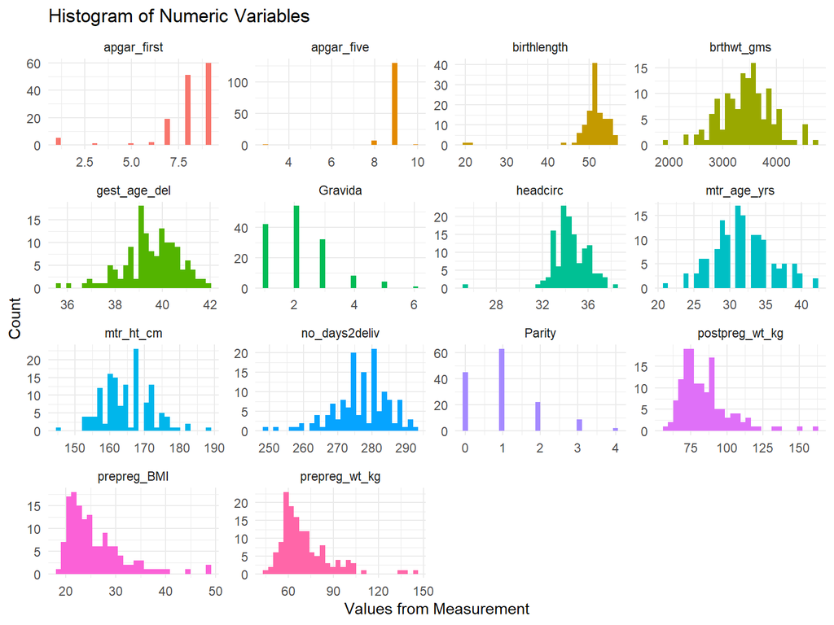

$$\\[0.5in]$$

### Categorical Variables

For these, we are interested in how many in each category, as well as the number of NAs. The following are the summary for these.

```
  marital_status   n
1              .   1
2              0  27
3              1 113
```

```
  smoking_stat  n
1            0 92
2            1 14
3            2 19
4            3  4
5            4  3
6            6  9
```

```
  smoking_cat   n
1           0 106
2           1  19
3           2   7
4          99   9
```

```
  ethnicity_synthesized   n
1                     0 115
2                     1   9
3                     2   3
4                     3   3
5                     4   1
6                     5   4
7                     7   6
```

```
  nonwhite   n
1        0 115
2        1  20
3       99   6
```

```
  race_3cat   n
1         0 115
2         1   9
3         2  11
4        99   6
```

```
  edu  n
1   1 19
2   2 15
3   3 57
4   4 50
```

```
  income_num  n
1          0 21
2          1 16
3          2 27
4          3 21
5          4 31
6          5 24
7          6  1
```

```
  occupation  n
1          0  5
2          1 10
3          2 12
4          3 52
5          4 37
6          5 25
```

```
  rod   n
1   0 102
2   1  39
```

```
  preterm   n
1       0 137
2       1   4
```

```
  pregcomp  n
1        .  3
2        0 92
3        1 46
```

```
  sex_word  n
1   Female 72
2     Male 69
```